# EXPLORACION_NUMERICAS

## Procesamiento y análisis de datos para clustering

Una de las primeras cosas que hicimos para poder hacer el agrupamiento de datos fue elegir cuidadoasamente las variables. Al igual que en ocasiones anteriores buscamos usar las variables numéricas para poder encontrar patrones en los datos. Pero incluso antes de elegir las variables numéricas, necesitamos ghacer algunas transofrmaciones que serán útiles en los resultados finales. Aquí hacemos un map (estructura llave valor), que es el código de causa de defunción con su respectiva descripción. Esto luego serapa útil al mostrar los resultados finales cuando se hayan asignado los grupos.

```r
# Crear hash map
diccionario_codigos_defuncion <- hash()

# Leer datos y cargarlos
diccionario_codigos_defuncion <- hash()

# Leer datos con encoding correcto
codigos_defuncion <- read.csv("codigo_defunciones.csv",
                            header = FALSE,
                            fileEncoding = "ISO-8859-1",  # encoding
                            stringsAsFactors = FALSE)

# Verificar si funciona el diccionario
head(codigos_defuncion)
```

```
##              V1                                                   V2
## 1 Código CIE-10                                          Descripción
## 2           A00                                               Cólera
## 3          A000 Cólera debido a Vibrio cholerae 01, biotipo cholerae
## 4          A001   Cólera debido a Vibrio cholerae 01, biotipo el Tor
## 5          A009                              Cólera, no especificado
## 6           A01                      Fiebres tifoidea y paratifoidea
```

```r
# Cargar datos en el hash
for(i in 1:nrow(codigos_defuncion)) {
  diccionario_codigos_defuncion[[codigos_defuncion$V1[i]]] <- codigos_defuncion$V2[i]
}

# Acceder a valores (ejemplo con tilde para corroborar el encoding funciona)
descripcion <- diccionario_codigos_defuncion[["A00"]]
print(descripcion)
```

```
## [1] "Cólera"
```

```r
guess_encoding("codigo_defunciones.csv")$encoding[1]
```

```
## [1] "ISO-8859-1"
```

```r
print(head(data,10))
```

```
##       Asist Añoreg Caudef      Depocu      Depreg Diaocu    Dnadif    Dredif
## 1    Médica      9   Y214   Escuintla   Escuintla      2 Guatemala Guatemala
## 2  Empírica      9   X919   Guatemala   Guatemala     27 Guatemala Guatemala
## 3  Empírica      9   X959     Jutiapa     Jutiapa     23 Guatemala Guatemala
## 4  Empírica      9   V899 El Progreso El Progreso      5 Guatemala Guatemala
## 5  Empírica      9   X709   Guatemala   Guatemala      7 Guatemala Guatemala
## 6  Empírica      9   X594   Escuintla   Escuintla     18 Guatemala Guatemala
## 7  Empírica      9   X954   Guatemala   Guatemala     10 Guatemala Guatemala
## 8  Empírica      9   X959   Guatemala   Guatemala     12 Guatemala Guatemala
## 9  Empírica      9   X599   Escuintla   Escuintla     11 Guatemala Guatemala
## 10 Empírica      9   X599   Escuintla   Escuintla      1 Guatemala Guatemala
##     Ecidif Edadif Mesocu Mesreg    Mredif            Ocur      Perdif   Sexo
## 1  Soltero     12      1      1 Guatemala Centro de salud 1 año y más Hombre
## 2  Soltero     16      9      9 Guatemala Centro de salud 1 año y más Hombre
## 3  Soltero     18      8      9 Guatemala Centro de salud 1 año y más  Mujer
```

[output cut: 18 more lines]

## limpieza de datos

Ya que pleaneamos usar el algoritmo de K-means para poder realizar el agrupamiento, filtramos variables que podrían ser redundantes y también casos extremos/atípicos. Nuestro set de datos tiene algunas particularidades interesantes para los casos extremos. Por ejemplo en el caso de la edad del difunto *Edadif*, las personas a la cuales no se les registro la edad estan marcadas con el numero 999. Entonces hay que filtrar dichos casos que pueden afectar el agrupamient, además de remover variables redundantes como Añoreg y mesreg sy ya tenemos el año de defunción y el mes de ocurrencia.

```
## Registros totales: 1167602
```

```
## Registros con edad desconocida (999): 8686 (0.7%)
```

```
## Registros válidos conservados: 1158916
```

```
## Variables numéricas encontradas: 4
## Nombres: Diaocu Edadif Mesocu year
```

```
##    Caudef
## 1    Y214
## 2    X919
## 3    X959
## 4    V899
## 5    X709
## 6    X594
## 7    X954
## 8    X959
## 9    X599
## 10   X599
##                                                                                              Caudef_descripcion
## 1                                     Ahogamiento y sumersión, de intención no determinada, calles y carreteras
## 2                               Agresión por ahorcamiento, estrangulamiento y sofocación, lugar no especificado
## 3                   Agresión con disparo de otras armas de fuego, y las no especificadas, lugar no especificado
## 4                                                    Persona lesionada en accidente de vehículo no especificado
## 5  Lesión autoinfligida intencionalmente por ahorcamiento, estrangulamiento o sofocación, lugar no especificado
## 6                                                   Exposición a factores no especificados, calles y carreteras
## 7                     Agresión con disparo de otras armas de fuego, y las no especificadas, calles y carreteras
## 8                   Agresión con disparo de otras armas de fuego, y las no especificadas, lugar no especificado
## 9                      Exposición a factores no especificados que causan otras lesiones y las no especificadas
## 10                     Exposición a factores no especificados que causan otras lesiones y las no especificadas
```

## Estadísticas descriptivas de los datos

Aquí nuevamente hacemos estadísticas descriptivas para ver el comportamiento de las variables y confirmar que no hay datos atípicos dentro de los datos con los que se realizará el clustering.

| Variable | Media | Mediana | Desv_Estándar | Mínimo | Máximo | Q1 | Q3 | IQR | N_NA |
| --- | --- | --- | --- | --- | --- | --- | --- | --- | --- |
| Diaocu | 15.67 | 16 | 8.81 | 1 | 31 | 8 | 23 | 15 | 0 |
| Edadif | 54.50 | 61 | 27.87 | 0 | 129 | 33 | 78 | 45 | 0 |
| Mesocu | 6.56 | 7 | 3.42 | 1 | 12 | 4 | 9 | 5 | 0 |
| year | 2016.01 | 2016 | 4.07 | 2009 | 2022 | 2013 | 2020 | 7 | 0 |

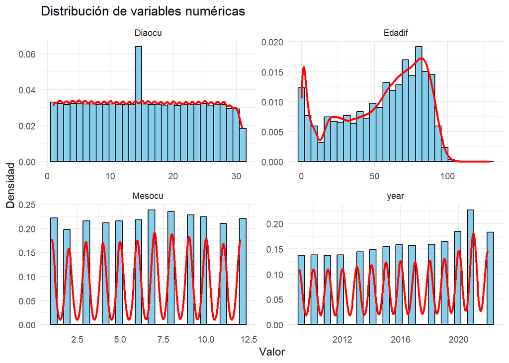

# Relaciones entre variables (clustering)

Una vez procesados los datos se realiza el análisis de agrupamiento.

## Estadistico de Hopkins

```
## [1] "Estadistico de Hopkins: 0.794113672762698"
```

Con el estadístico de hopkins se obtuvo una valore de 0.794113672762698, el estadístico indica que los datos tienen una tendencia a poder ser agrupados, pero este número también nos indica que el agrupamiento de los datos puede que no sea tan fuerte al estar un poco alejado de un valor de 1. Tomando en cuenta las variables elegidas y que tenemos pocas variables numéricas, tiene sentido que el agrupamiento puede que no sea tan fuerte o distinguido. La situación de clustering no es ideal, pero es posible realizar agrupamiento aún con estas condiciones.

## Grafico de codo

Para obtener el número de grupos para el algoritmo de K-means, realizamos el gráfico de codo, obteniendo los soguientes resultados:

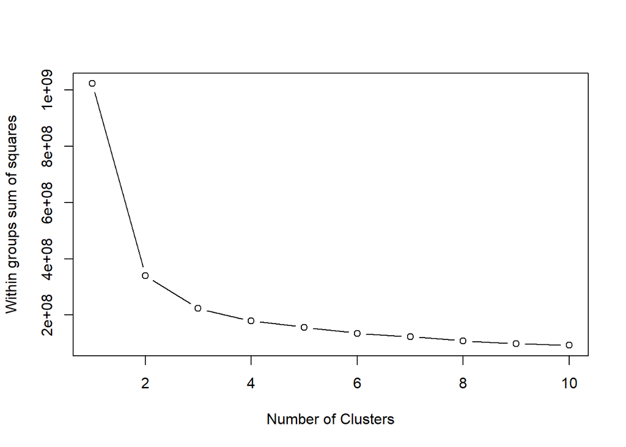

Claramente el códo de la gráfica se encuentra en 2 o bien 3 clusters. Luego de hacer distintas pruebas determinamos que la mejor opción sería una cantidad de 3 grupos para poder tener más insightts sobre las defunciones en Guatemala. Utilizando 3 grupos y el algoritmo de K-means se obtiene el siguiente diagrama de clusters.

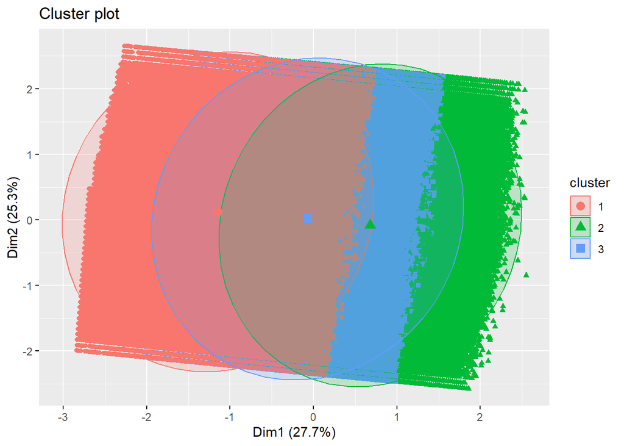

Con estos resultados podemos ver que realmente el algoritmo ha tenido dificultades para encontrar grupos realmente separados entre sí. Por las elipses se puede notar que los grupos se intersecatn bastante entre si, pero esto era de esperarase tomando el cuenta el estadístico de hopkins. Pero a pesar de esto, se nota ver que si hay algunas regiones que están diferenciadas de los demás clusters, pero en general el agrupamiento con los datos seleccionados no es óptimo de momento.

```
## [1] -0.004869132
```

```
##   cluster size ave.sil.width
## 1       1 2503          0.00
## 2       2 4475         -0.01
## 3       3 3022          0.00
```

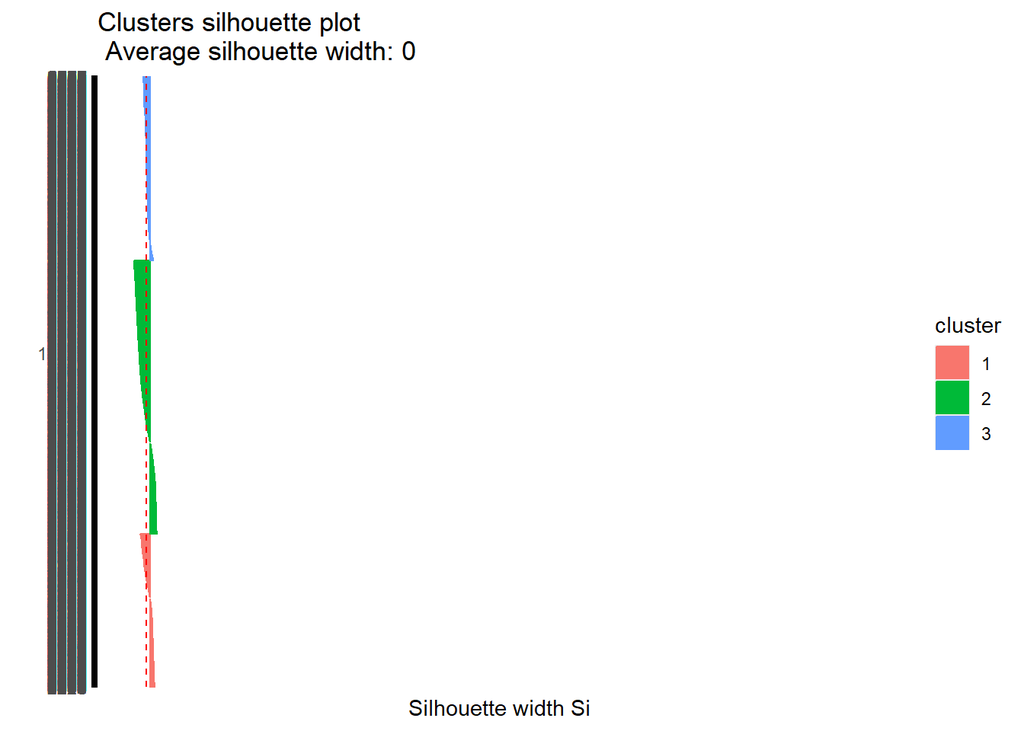

Además de la representación visual de los grupos realizamos el estadístico de silueta para determinar que tan bueno fue el agrupamiento. Debido a la cantidad de datos (más de 1 millon), tuvimos que tomar una muestra del set de datos para poder realizar el estadístico, ya que el propio algoritmo tiene un límite de espacio. Utilizando unamuestra al final se obtuvo un valor de silueta promedio de *“-0.004869132”*. Con el estadístico de silueta lo que se obtiene es un número en el intervalo de -1 a 1. Un valor cercano a 0, como el de este caso, quiere decir que realmente los grupos se traslapan y las variables de un grupo podrían pertenecer a otro. Tomando en cuenta el análisis que vimos al principio puede que las variables numéricas en este caso no hayan sido ideales, pero aún con estos resultados neutros, se ha podido realziar un agrupamiento que se analizará a continuación.

El agrupamiento fue realizado con 4 variables al final: el año, mes , dia de ocurrencia y la edad. Realmente estas primeras 3 no ayudaron mucho en el agrupamiento de los datos, algo que era de esperarse tomando en cuenta la distribución de los datos que se vió al principio. Seguramente fue por lo poca tendencia de agrupamiento de estas variables que el agrupamiento no fue tan efectivo. No obstante y como se muestra a continuación, los datos si pudieron agruparse por la edad de las personas.

```
##      Asist Caudef      Depocu      Depreg Diaocu    Dnadif    Dredif  Ecidif
## 1   Médica   Y214   Escuintla   Escuintla      2 Guatemala Guatemala Soltero
## 2 Empírica   X919   Guatemala   Guatemala     27 Guatemala Guatemala Soltero
## 3 Empírica   X959     Jutiapa     Jutiapa     23 Guatemala Guatemala Soltero
## 4 Empírica   V899 El Progreso El Progreso      5 Guatemala Guatemala Soltero
## 5 Empírica   X709   Guatemala   Guatemala      7 Guatemala Guatemala  Casado
## 6 Empírica   X594   Escuintla   Escuintla     18 Guatemala Guatemala Soltero
##   Edadif Mesocu    Mredif            Ocur      Perdif   Sexo    Mnadif year
## 1     12      1 Guatemala Centro de salud 1 año y más Hombre Guatemala 2009
## 2     16      9 Guatemala Centro de salud 1 año y más Hombre Guatemala 2009
## 3     18      8 Guatemala Centro de salud 1 año y más  Mujer Guatemala 2009
## 4     18     12 Guatemala Centro de salud 1 año y más Hombre Guatemala 2009
## 5     19      5 Guatemala Centro de salud 1 año y más  Mujer Guatemala 2009
## 6     20     10 Guatemala Centro de salud 1 año y más Hombre Guatemala 2009
##    Escodif
```

[output cut: 20 more lines]

# Graficos relevantes por grupo

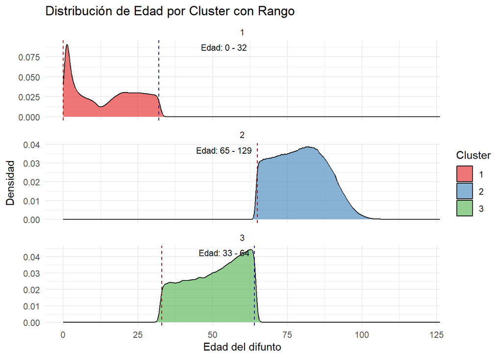

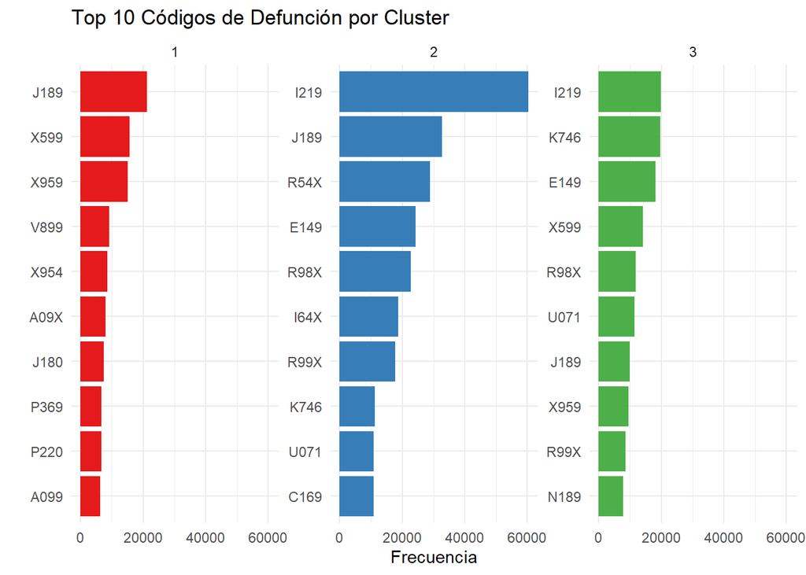

Descripción de Códigos de Defunción

Referencia para el gráfico 'Top 10 por Cluster'

| Código | Descripción Completa |
| --- | --- |
| 1 |  |
| A099 | Gastroenteritis y colitis de origen no especificado |
| A09X | Código no encontrado |
| J180 | Bronconeumonía, no especificada |
| J189 | Neumonía, no especificada |
| P220 | Síndrome de dificultad respiratoria del recién nacido |
| P369 | Sepsis bacteriana del recién nacido, no especificada |
| V899 | Persona lesionada en accidente de vehículo no especificado |
| X599 | Exposición a factores no especificados que causan otras lesiones y las no especificadas |
| X954 | Agresión con disparo de otras armas de fuego, y las no especificadas, calles y carreteras |
| X959 | Agresión con disparo de otras armas de fuego, y las no especificadas, lugar no especificado |
| 2 |  |
| C169 | Tumor maligno del estómago, parte no especificada |
| E149 | Diabetes mellitus no especificada, sin mención de complicación |
| I219 | Infarto agudo del miocardio, sin otra especificación |
| I64X | Accidente vascular encefálico agudo, no especificado como hemorrágico o isquémico |
| J189 | Neumonía, no especificada |
| K746 | Otras cirrosis del hígado y las no especificadas |
| R54X | Senilidad |
| R98X | Muerte sin asistencia |
| R99X | Otras causas mal definidas y las no especificadas de mortalidad |
| U071 | COVID-19, virus identificado |
| 3 |  |
| E149 | Diabetes mellitus no especificada, sin mención de complicación |
| I219 | Infarto agudo del miocardio, sin otra especificación |
| J189 | Neumonía, no especificada |
| K746 | Otras cirrosis del hígado y las no especificadas |
| N189 | Enfermedad renal crónica, no especificada |
| R98X | Muerte sin asistencia |
| R99X | Otras causas mal definidas y las no especificadas de mortalidad |
| U071 | COVID-19, virus identificado |
| X599 | Exposición a factores no especificados que causan otras lesiones y las no especificadas |
| X959 | Agresión con disparo de otras armas de fuego, y las no especificadas, lugar no especificado |

Lo primero es analizar las principales razones de defunción por cluster (edad), recordemos que el cluster 1 son las personas jovenes, 3 las personas adultas y el 2 personas mayores. En este caso se mantiene el código en el gráfico de barras por fines de presentación, ya que las descripciones de algunos son demasiado largas. Pero por cada cluster se incluye también una tabla para los códigos correspondientes. Ahora ya entrando en el análisis, en el caso de las personas jovenes las enfermedades más comunes parecen ser la Neumonía (J189), “Exposición a factores no especificados que causan otras lesiones” (X599), Agresión con disparos de armas de fuego (X954, X959) y lesiones en accidentes vehiculares (V899).

En el caso del grupo 3, las razones más comunes son Infartos (I219), Cirrosis de hígado (K746), Diabetes mellitus (E149), “Exposición a factores no especificados”, muerte sin asistencia (R98X) y Covid-19 (U071). Finalmente el grupo con las personas mayores (grupo 2), las principales razones son: infartos, neumonía, senilidad (R54X), Diabetes mellitus, muerte sin asistencia y Accidente vascular encefálico agudo (I64X).

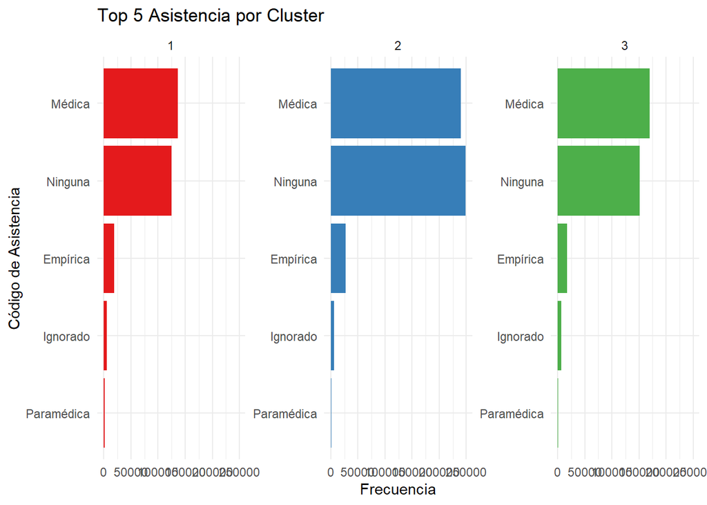

Como se puede ver en el gráfico, si hay intervención considerable del equipo médico, pero muchas personas independientemente de la edad no recibieron asistencia y la intervención de equipo paramédico parece ser muy poca. Se ve claramente que hay un gran problema con la asistencia a personas en riesgo por enfermedad o accidentes. Y encima de esto, se puede ver que hay falta de intervención medica si analizamos el lugar de ocurrencia por cada uno de los grupos.

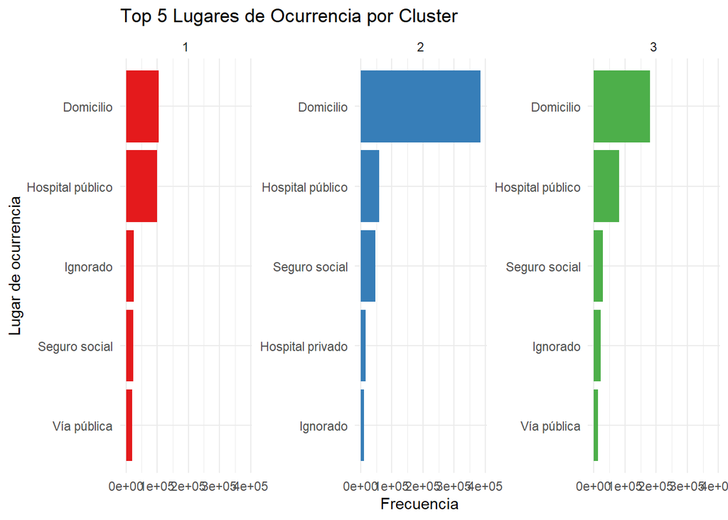

Podemos ver que sin importar el rango de edad, el lugar de defunción más común es el domicilio de la persona, seguido por el hospital público pero hay una gran diferencia entre ambos, excepto en el caso de las personas más jóvenes (cluster 1). Las personas seguramente no atienden al hospital, pero con estos datos específicos es difícil conocer el porqué. Probablemente por falta de atención, dificultad de acceso, negligencia, entre otros. Lo que es interesante es que las personas menores de 30 años (aproximadamente) parecen ser más propensas en proporción a haber fallecido en hospitales. En un punto pensamos que tal vez la ubicación podría haber influido grandemente en las defunciones, habiendo menos asistencia médica en áreas rurales del país. En el sigiuetne gráfico se pone a prueba dicha suposición.

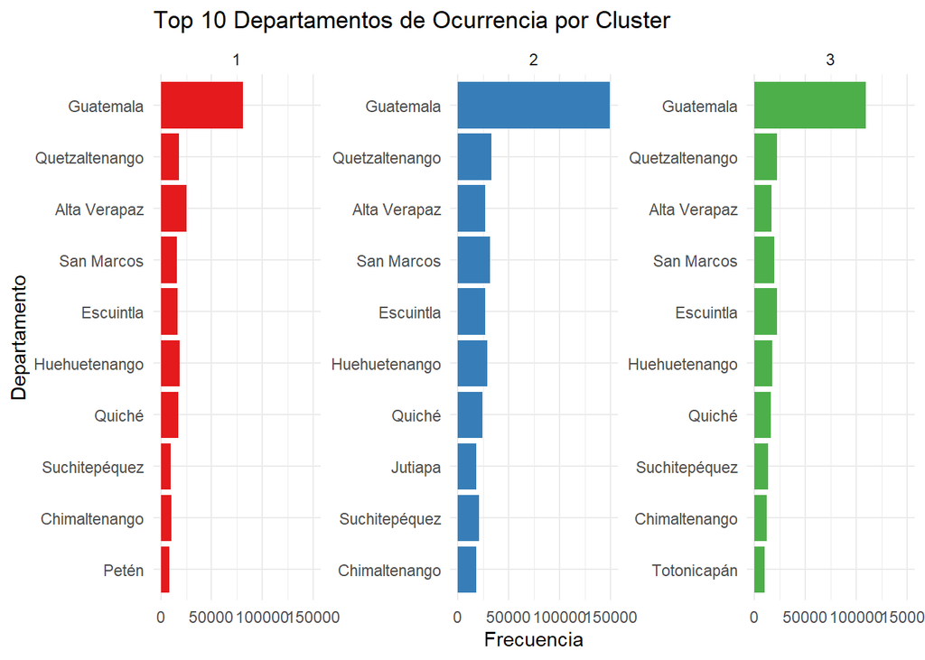

Pero al final como se puede observar realmente el lugar con más defunciones es el área más urbanizada. Seguramente porque la densidad de población en la capital es mayor, hay muchas más personas en la capital Ciudad de Guatemala que en los demás departamentos. Realmente el lugar de defunción no parece tener relación alguna con la edad, el comportamiento parece ser el mismo con todos los grupos. Ahora que hemos analizado la atención y ubicación de las defunciones, podemos analizar si hay algún patrón en las fechas, tomando en cuenta el año o bien los meses.

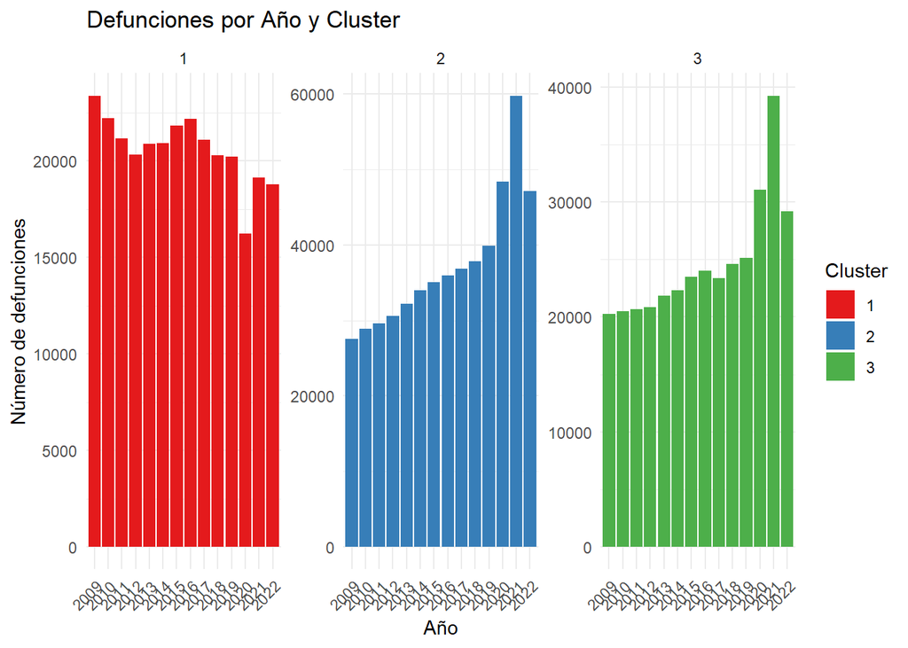

Parece que la mortalida fue disminuyendo en las personas menores de 30 años (cluster 1), menos personas jovenes estan falleciendo de forma prematura con el paso de los años recientemente. Pero para el resto de las edades mayores, la mortalidad a ido en aumento, habiendo un incremento enorme en los años 2020 y 2021. Esto se debe seguramente por las defunciones masivas que que lastimosamente se dieron a causa de la pandemia Covid-19. Durante ese periodo de tiempo muchas personas enfermaron y quienes fueron más afectados fueron las personas mayores. En esos 2 años, muchas personas fallecieron a causa del virus o bien por alguna enfermedad que se vió agravada por la presencia del virus en el cuerpo de las personas. El pico es definitivamente un resultado de la pandemia. Sabiendo esto, podemos confirmar y profundizar ahora en cuales fueron las principales causas por año.

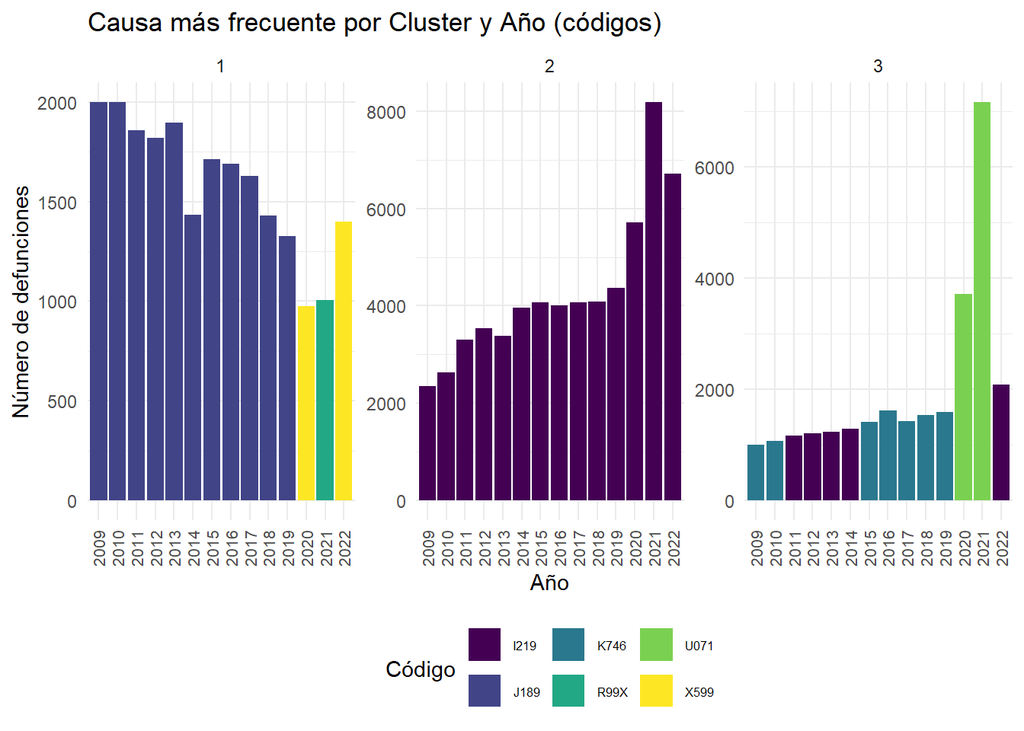

```r
# Gráfico con códigos (en lugar de descripciones)
grafico <- ggplot(top_causas, aes(x = as.factor(year), y = n, fill = Caudef)) +
  geom_col() +
  scale_fill_viridis_d(option = "D", name = "Código") +  # Paleta alternativa
  labs(
    title = "Causa más frecuente por Cluster y Año (códigos)",
    x = "Año",
    y = "Número de defunciones"
  ) +
  theme_minimal() +
  facet_wrap(~Cluster, scales = "free_y") +
  theme(
    axis.text.x = element_text(angle = 90, hjust = 1, vjust = 0.5, size = 8),
    legend.position = "bottom",
    legend.text = element_text(size = 6)
  )

print(grafico)
```

```r
tabla_referencia <- top_causas %>%
  distinct(Caudef) %>%  # Elimina duplicados
  left_join(
    codigos_defuncion %>% rename(Caudef = V1, Descripción = V2),
    by = "Caudef"
  ) %>%
  arrange(Caudef) %>%  # Ordenar alfabéticamente
  gt() %>%
  tab_header(
    title = "Descripción de códigos de defunción",
    subtitle = "Referencia única para el gráfico"
  ) %>%
  cols_label(
    Caudef = "Código",
    Descripción = "Descripción completa"
  ) %>%
  tab_style(
    style = cell_text(weight = "bold"),
    locations = cells_column_labels()
  )

tabla_referencia
```

Descripción de códigos de defunción

Referencia única para el gráfico

| Código | Descripción completa |
| --- | --- |
| I219 | Infarto agudo del miocardio, sin otra especificación |
| J189 | Neumonía, no especificada |
| K746 | Otras cirrosis del hígado y las no especificadas |
| R99X | Otras causas mal definidas y las no especificadas de mortalidad |
| U071 | COVID-19, virus identificado |
| X599 | Exposición a factores no especificados que causan otras lesiones y las no especificadas |

En el caso de las personas más jovenes, la razón de defunción más comun había sido la Neumonía(J189) hasta el 2020, de este año en adelante predominan otras causas, pero que lastimosamente no están bien identificadas. Ambos códigos (X599 y R99X) hacen referencia a motivos de defunción no especificados. Por otra parte en el caso de las personas del grupo 3 (personas de edad intermedia) la principal razón de defunción alterna entre Infartos (I219) y Cirrosis (K746), a excepción delos años de pandemia donde la principal razón de defunción fue el Covid-19. En el caso de las personas de mayor edad (grupo 2) realmente la principal causa no ha cambiado, en todos los años el principal motivo fue infartos, incluidos los años de pandemia. Algo que refuerza la idea que el virus de pandemia fue letal no solo por el propio virus sino por el debilitamiento del cuerpo, exponiendolo a otras enfermedades y empeorando la salud en general.

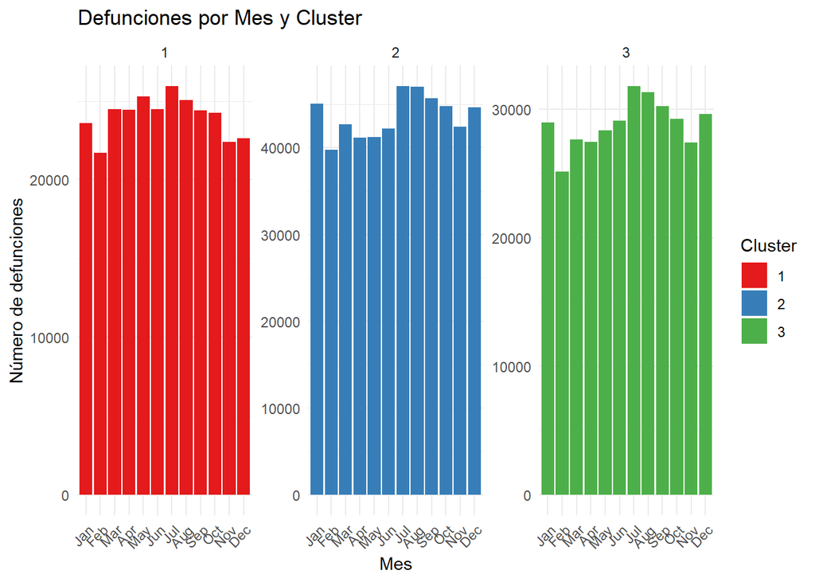

Ahora con respecto a las defunciones por mes, realmente parece que no hay relación alguna con la edad. En los 3 grupos el comportamient es el mismo. No obstante nos gustaría destacar que los meses en los cuales pareciera haber más defunciones, aunque la diferencia no sea tanta, es a mediados de año específicamente en los meses de Julio y Agosto. Por el lado contrario febrero parece ser el mes donde ocurren menos defunciones. Ahora lo último que nos queda por analizar, es la información relacionada a la informacíon demográfica, para determinar si algún factor social puede estar influyendo en la cantidad de defunciones.

## AHora con datos demográficos

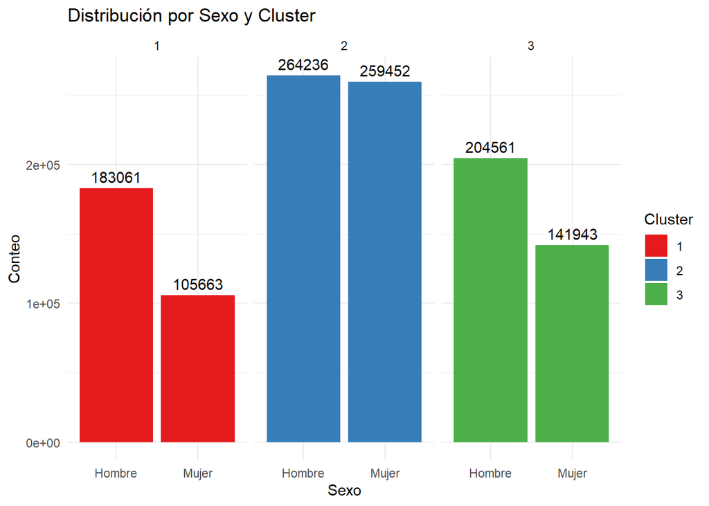

En todos los casos, hay más defunciones de hombres que mujeres, independientemente del rango de edad. La única diferencia es que a medida que el grupo de edad es mayor la diferencia entre la cantidad de difuntos por sexo disminuye. Por ejemplo en el grupo 2 (las personas de mayor edad), la cantidad de difuntos casi no varía dependiendo del sexo. A diferencia de las personas menores a 60 años (grupos 1 y 3) done se ve claramente que los homrbres son más propensos a fallecer o al menos hay más defunciones en el sexo másculino.

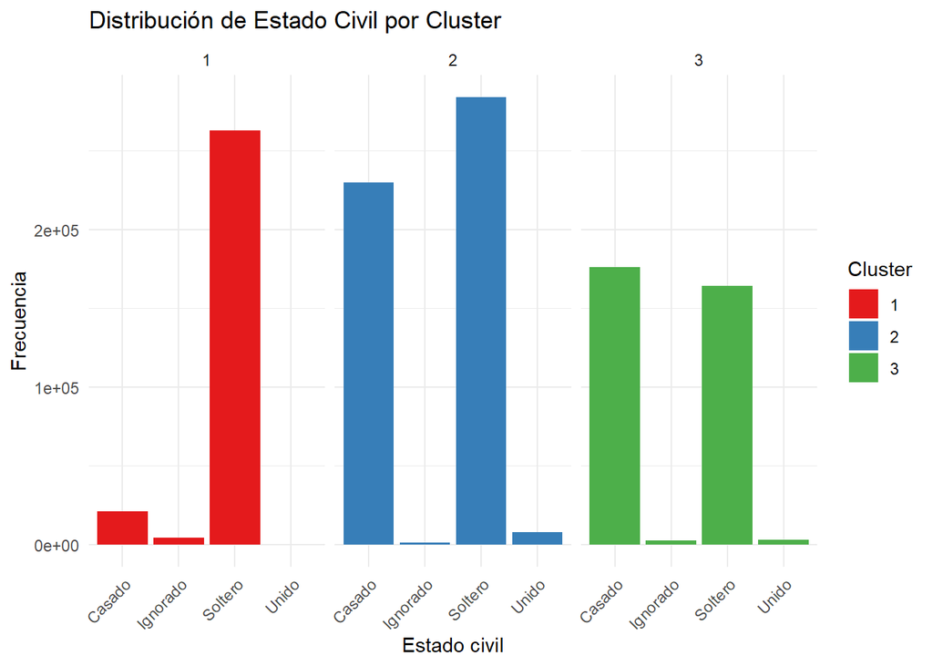

En este caso no parece haber mucha correlación entre la cantidadd de defunciones con el tipo de estado civil. El punic que parece mostrar una diferencia significativa es el grupo 1, donde se ve que los difuntos son casi todos solteros, pero recordemos que este es el grupo con las personas más jovenes. Por lo que es de esperarse que la mayorái de las personas hayan fallecido estando solteros, ya que en este rango de edad se incluyen a personas menores de edad. En los otro grupos la diferencia no es tan grande.

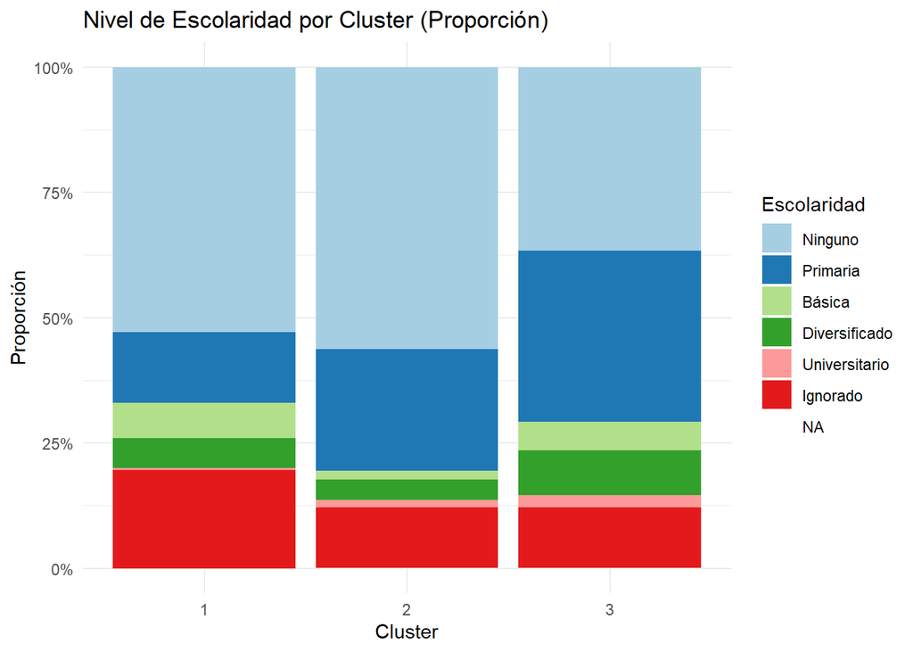

Por último tenemos el nivel de escolaridad de las personas, aquí encontramos un indicador interesante. De todas las personas, independientemente del rango de edad, el nivel de escolaridad es bastante bajo. Cuando en el grafico decimos que el nivel es “Ninguno” no se refiere a que no se conoce, el caso cuando no se conoce es NA o bien “Ignorado”. En este gráfico podemos ver que en todos los grupos el nivel de educación es demasiado bajo. Ahora bien, podríamos decir que hay una correlación entre la escolaridad y las defunciones y decir que la mayoría de personas fallecidas son las que no alcanzan un nivel de educación alto. Pero con este gráfico es dificil determinarlo con certeza. Este gráfico no necesariamente podría representar una correlación entre defunciones y escolaridad, puede ser un indicador de que el nivel de la educación de las personas del país en general es bajo. A tal punto que sin importar la edad, las personas tienen menor escolaridad.